# Challenge

As a reminder, we have dealt with two systems so far in this course that look very different, but behave in very similar ways. Both the blue toy truck slowing down from a nonzero initial velocity and the tank draining through an open valve seemed to show behavior that could be described by a *differential equation,* in which the change in system outputs was dependent on how large the output was.

In Reading 7, we saw that building a physics-based model of the toy truck problem gave us insight into how the system's behavior might change if we changed its properties. Using Newton's second law, we found a model for the truck's coasting behavior as:

$$ \dot{v} = - \frac{1}{m_c+2m_w+2\frac{J}{r_{wg}^2}} \left[ 2\frac{b}{r_{wg}^2} v \right]$$

What we did not do in reading 7 is discuss how changing the truck's parameters affects its behavior. We also did not evaluate the model we derived! Below, see a comparison between Euler integration for our physics-based model and data. Feel free to change parameters like wheel mass, damping coefficient, and car mass to see what effects these have on the truck's behavior. While changing these will make the model fit the data more poorly, they do tell us what would happen if we changed the truck's properties.

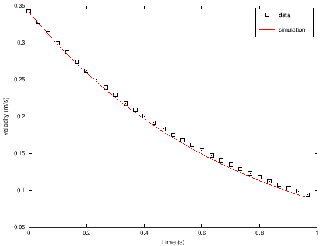

```matlab
% clear variables
clear all

%load the data we will use for model validation
data = load('reading6data.txt');
td = data(:,1);
vd = data(:,2);

%set up a new time and velocity vector to use for simulation
dt = .01;
simtime = td(end);
tsim = 0:dt:simtime;
vsim = vd(1);

%define the measured parameters for the toy truck parts
mc = .05; %kg, truck mass
mw = .01; %kg, mass of one axle, including 2 wheels
rw = .005; %m, radius of wheels
Jw = 1/2*mw*rw^2;
b = .055;

%use Euler integration to simulate our model
for k=2:length(tsim)
    %compute acceleration using model
    vdot = -2*b/(1^2*(mc+2*mw+2*Jw/rw^2)) * vsim(k-1);
    vsim(k) = vsim(k-1) + vdot*dt;
end

%compare model with data to evaluate
figure
plot(td,vd,'ks',tsim,vsim,'r')
xlabel('Time (s)')
ylabel('velocity (m/s)')
legend('data','simulation')
```

But this model came from Newton's laws, which would be difficult (not impossible, but difficult) to apply to the draining tank. The water in the tank is not a rigid body, so a free body diagram does not seem like the right tool. But imagine if there was a way to approach the tank-drain problem in the *same way* as the blue toy truck problem, using some "grand unifying quantity" that applies similarly to both systems. As it turns out, there is such an approach, and it is based on a concept that you are probably already familiar with from high school physics: Energy.

In this assignment, your challenge is to be able to develop a model for a system based on how it *exchanges energy* with its environment. Your assignment will be an experiment of sorts. We need to determine whether we have the tools we need to revisit reading 8, in which you derived a model for a mass-pulley system based on Newton's laws, and build the same model using an energy-based approach.

To prepare you for the assignment, we will proceed by example, and look at how to derive the model for the toy truck in a similar fashion. Before we begin, we will need to look at a few key concepts. The first one, the biggest, is energy.

## Energy

In one of his famous lectures, now available [online](https://www.feynmanlectures.caltech.edu/I_04.html), Nobel Prize-winning physicist Richard Feynman stated:

"It is important to realize that in physics today, we have no knowledge of what energy *is*."

What does he mean? Well, the human-made concept of "energy" has a [long and storied history](https://www.amazon.com/Warmth-Disperses-Time-Passes-Paperback/dp/0375753729/ref=sr_1_2?keywords=history+of+heat&qid=1582497717&sr=8-2). In essence, the concept was created to describe what scientists reliably **observe** when conducting experiments.

Let's proceed by example. If you rub your hands together, this involves "doing work." what is the result of this work? Your hands increase in temperature. If you place a ball on top of a hill, and let it roll down, it will have a predictable amount of velocity when it reaches the bottom of the hill. If I apply heat to a balloon full of air, it will expand. Energy is something "we" have come up with to link the relationships between **the work done on a system** and the **heat** a system exchanges with its environment. Specifically, based on repeated observation through the centuries, scientists accept the following about energy:

- Energy is neither created nor destroyed.

- For a system in which no mass crosses the boundary of the system definition, *Work* and *Heat* describe the only two ways we know of that a system can *exchange* energy with its surroundings. If the mass contained in a system's boundaries changes, then this change of mass can also result in a transport of energy.

To understand how to use these observations about "energy," we must first be specific about what we mean by "work" and "heat."

## Work

Work, in the thermodynamic sense, is what occurs when a system exerts forces on its surroundings whose effects can be measured. Work can be produced by a pressure applied in order to change a system's volume, or by a force that physically moves a rigid body, or by an electric field that moves a charged particle. Work is usually expressed as a capital $W$, and has SI units of $Nm$ or "Joules."

Most relevant to our current challenge is *mechanical work*, which is measurable if one knows the quantity of an applied force (or toque) and the distance (or angle) over which it was applied.

### Mechanical Work via a Force

Mechanical work is the product of a force and a distance. Specifically, work is the *integral* of force applied along a path.

$$W_{a\rightarrow b} = \int _\vec{a}^{\vec{b}} \vec{F}\cdot d\vec{S}$$

Consider a situation in which you are pushing a block of wood around on a table. By modeling the interaction between the block and the table using dry friction, where $F_f = \mu m g$, we can imagine that if the block of wood is moving at all times, the friction force applied to resist us pushing it around is constant, and always opposing motion. Imagine that you could choose to push the block along two possible paths, $S_1$ or $S_2$. The destination is the same, but $S_1$ is much longer.

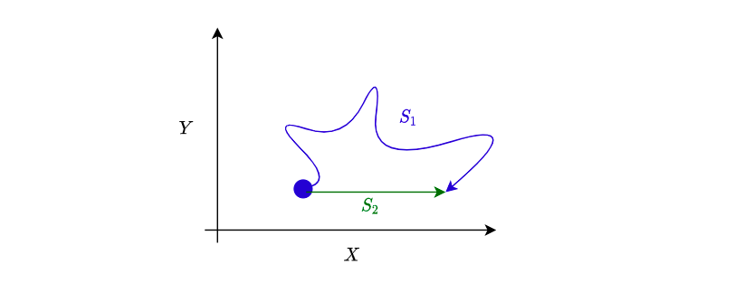

you might imagine that path $S_1$ would colloquially "take more work" to achieve, or "drain more of your energy." This is consistent with the formal definition of work!

## Mechanical Work via a Torque

In an analagous sense to the definition of mechanical work via a force, mechanical work is produced when a torque is applied to an object which moves through some angle. Formally, we can say:

$$W_{\theta_1 \rightarrow \theta_2} = \int_{\theta_1}^{\theta_2} T d\theta$$

Because torque has units of $Nm$, we find that in SI units, with radians as our measure of angle, mechanical work has the same units as it does for translation: $\frac{kgm^2}{s^2}$, which is equivalent to $Nm$ or Joules.

In our toy truck problem, we have *viscous damping* from the bearing that does work on the truck to slow it down. This work is produced by a torque that depends on the angular velocity of the bearing, as we learned in Reading 7.

## Heat

When people think of "heat," they usually think of temperature. Temperature is certainly a measure of the *intensity* of heat, but the way that we measure the *quantity* of heat is in terms of the energy it takes to raise a system's temperature. Because not all systems' temperatures can be changed with the same ease, temperature itself is not enough to describe the magnitude of "heat." For example, we could imagine that while a candle will burn our fingers almost immediately, it could not be expected to raise a large pot of water to its boiling point just as quickly.

In general, raising temperature is accomplished by either transferring heat from a hot object to a cold object, or by *doing work* that is converted to heat, such as when you rub your hands together to warm them up. In most of thermodynamics, the quantity of heat is denoted with the letter $Q$. Heat, in base SI units, does not have units of calories-- like work, and like measures of kinetic and potential energy, it has units of "Joules," or $Nm$.

## Translational and Rotational Kinetic Energy in a Rigid Body

When a rigid body is moving, we say that it "stores" *translational kinetic energy,* which it can then exchange with its surroundings. The translational kinetic energy in a rigid body is:

$$E_k = \frac{1}{2}mv^2$$

Where $v$ is the scalar *magnitude* of its overall velocity. In SI units, this energy has units of Joules, or $\frac{kgm^2}{s^2}$.

When a rigid body rotates, it stores *rotational kinetic energy*. Rotational kinetic energy, which also has units of Joules, is given by:

$$E_k = \frac{1}{2}J\Omega^2$$

Where $\Omega$ is the magnitude of the angular velocity of the object (in $\frac{rad}{s}$ for SI units) about its center of mass, and $J$ is the mass moment of inertia of the object about its center of mass (in $kgm^2$ in SI units).

In our toy truck problem, the truck stores kinetic energy translationally for the truck body, which does not rotate, and both translationally and rotationally for the axles, because they both rotate about their CG and translate with the truck.

In modeling the truck as an *Energetic Physical System*, we can employ the fact that energy is always conserved to help us develop our model for the truck's motion. The law of conservation of energy, which states that energy is neither created nor destroyed, has another name: the "First Law of Thermodynamics."

## The First Law of Thermodynamics: The conservation of Energy

The first law of thermodynamics, also called "the conservation of energy," states that energy is never created nor destroyed... merely exchanged between a system and its surroundings. It is this law that tells us that [perpetual motion machines cannot exist](https://en.wikipedia.org/wiki/Perpetual_motion), as they produce work without the input of energy from outside of the system.

Because energy can only be transferred through either work or heat in a closed system, we can draw the relationship between a system of interest and its surroundings using the following diagram:

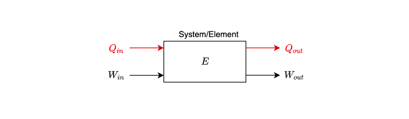

You may notice that this looks like our "system scope" diagram, but it deals with energy only. We represent internal (stored) energy, work done on the system from the external environment, work done *by* the system on its external environment, heat applied *to* the system from the external environment, and heat applied *by* the system to its external environment explicitly. Formally, we can write the change in energy *stored* inside the system from some "initial state" 1 to some "later state" 2 using the following equation, which is a statement of the first law:

$$ E_2 - E_1 = \Delta E = \delta W_{in} - \delta W_{out} + \delta Q_{in} - \delta Q_{out}$$

This says that if the balance of energy transfer between our system and its environment can be interpreted as the environment "doing work" on or "transferring heat to" our system of interest, it will increase the amount of energy stored *inside* our system if our system did not do work on its environment, or exchange heat with its environment.

In the opposite scenario, if balance of energy transfer between our system and its environment can be interpreted as our system "doing work" on its surroundings or "transmitting heat to" its surroundings, we say that the amount of energy stored in our system goes down.

If we consider that bringing our system from "energy state 1" to "energy state 2" requires time (which it always will), we can say that the *rate of change in energy in our system* can be written as:

$$ \frac{E_2 - E_1}{t_2-t_1} = \frac{\Delta E }{\delta t}= \frac{\delta W_{in}}{\delta t} - \frac{\delta W_{out}}{\delta t} + \frac{\delta Q_{in}}{\delta t} - \frac{\delta Q_{out}}{\delta t}$$

Shrinking $\delta t$ to an infinitesimal value leads to the derivative of our original first law equation, which is a totally equivalent statement about the conservation of energy:

$$ \dot{E} = \dot{W}_{in} - \dot{W}_{out} + \dot{Q}_{in} - \dot{Q}_{out}$$

The derivative of energy (and thus, the derivatives of power and heat) have units of $\frac{J}{s} = \frac{kgm^2}{s^3}$, which are commonly called "Watts" in SI units. There is also a very special name for the time-derivative of energy, and it is **power**.

## Power

Power is the time derivative of energy. In SI units, power has units of "Watts," or Joules per second. Power can take many forms, including thermal, mechanical, and electrical.

## Challenge Continued

Let's see how we might use the conservation of energy to build a model of our toy truck. Remember that because we used Newton's **laws** of motion to derive our model before, we should get the **exact same model** for our truck if we use **the first law of thermodynamics** since both approaches should be consistent with our physical understanding of the world (this is what a "law" of nature implies).

## Challenge Continued

Let's think about how we might apply the first law of thermodynamics to help us develop our model. We know (from observation, over hundreds of years of experiments) that energy is neither created nor destroyed, and we know that at the beginning of our model's "existence," we chose to give the truck an initial velocity, without much care for **how** that velocity was produced. But let's think about that for a second. In order to speed the truck up, something had to *do work on it* to transfer energy to it. Once it stops, it will have no internal kinetic energy left... so we already know that it must have transferred all of the energy transmitted to it to speed it up back to its environment as either work or heat.

To get a little more quantitative with this discussion, let's create a model scoping diagram that explicitly accounts for energy **only**. We will call this type of scoping diagram an *energetic diagram.*

## Energetic Diagrams

For this course, an energetic diagram will be defined as a diagram that **explicitly shows how we will model energy that is exchanged between the system (or a subsystem or an element) and its environment.** "How we will model" is important here. In drawing certain arrows that represent energy transfer, we will often make assumptions about *how* this energy is transferred and *with what.* Because these will often be simplifications, it is important to keep in mind that the energetic diagram is not "truth" by default. It is a model.

Arrows pointing in to the system should reflect outside influence from the system's surroundings that would *increase* its energy in the absence of other factors. These influences could be in the form of either heat or work as a function of time. Arrows pointing out of the system should reflect work or heat that a system transfers *to* its environment. In the absence of other factors, an outward-pointing arrow would decrease the amount of energy stored within a system.

More specifically, arrows represent a *flow of power* between a system and its surroundings, which can either be a known subsystem that is also being modeled, or a system's unmodeled, external surroundings ('the universe,' for instance). An example for an arbitrary system is shown below:

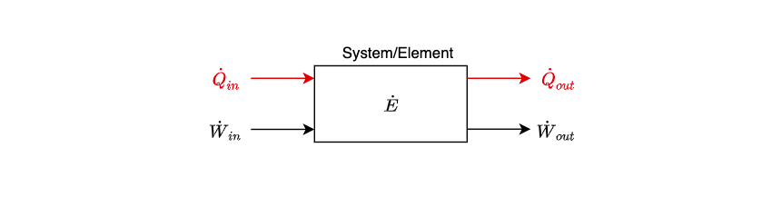

## Challenge Continued

If we would like to draw an energetic diagram for our toy truck, we will first stick with our overall system definition. We should ask: If the truck is at some initial energy state, how will it exchange that energy with its environment?

We know that because there is a fixed amount of mass in the truck, no kinetic energy will literally "escape" the system boundaries, so any energy exchange will either be because the truck "did work" on its environment, or because heat was transferred to its environment. Here, the truck's "environment" could be considered to be the surface upon which it rolls, and the air around it.

Mechanical work is the product of a force and a distance, so if **we neglect air resistance** (because for now we don't know how to model that piece), we can say that the truck actually does **no** work on its surroundings, since there is no measurable slip between the tires and the ground. At any moment, the point of contact between the tires and the ground is stationary, so the product of force times distance due to this contact is zero.

that means that **all** of the energy the truck transfers to its surroundings must be transferred as **heat.** With this simplification, we can represent our toy truck model with the following energetic diagram.

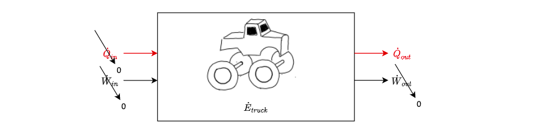

As you can see, the energetic diagram shows us that when we look at the whole scope of our system, we should be able to account for all of the change in the system's energy by accounting for the heat that the system exchanges with its environment. Note that this is implicitly a **model construction** step as well as a scoping step. If the truck's tires were to slip, or if its bumper fell off, this diagram may be invalid, because our modeling assumptions about the truck's mass and the tires' rolling without slip would be violated.

But because this diagram tells us very little about *how* that heat is transferred between the truck and its environment, we need to break the system up into smaller chunks, like we did when applying Newton's laws.

In Reading 7, we decided that there were three main subsystems of the toy truck that were important to us: The axles, the bearings, and the body of the truck. In Reading 7, we broke the scope down to include each bearing and axle as a separate piece, but in the end, we considered the contributions of the front and rear axles as equal . This means that a three-element scope makes sense. I have reproduced our "broken out" scope as an energetic diagram below.

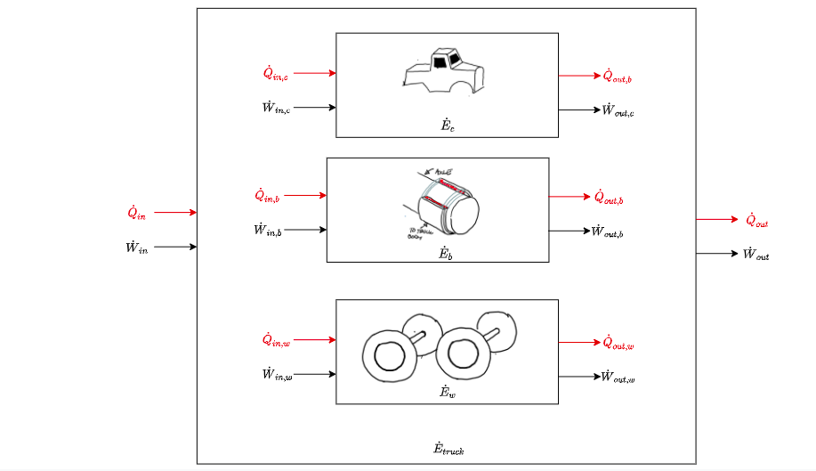

If we consider each of these pieces individually, we can actually develop an energetic diagram that includes power flow (energy transfer over time) between each of these subsystems or "elements" that represent the "whole" toy truck system.

Before we do that, though, let's look at a first-law analysis for each individual element in our toy truck model.

### First Law analysis of the toy truck's axles

A general energetic diagram for the axle is presented below.

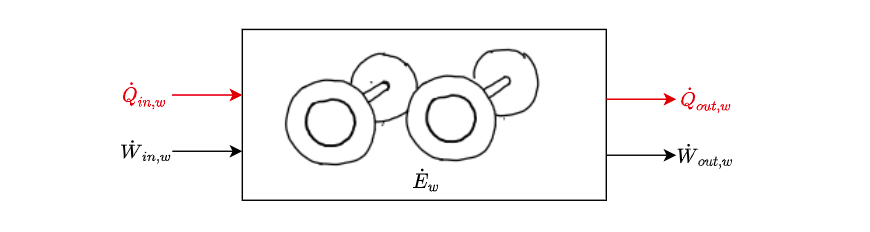

At this point, all we can do is write the first law based on the diagram above.

$$\dot{E}_w = \dot{W}_{in,w}-\dot{W}_{out,w} + \dot{Q}_{in,w}-\dot{Q}_{out,w}$$

How can we fill these terms in? Let's start with what we know. For the axles, whose masses don't change, we can write the following expression for the energy "stored" in them as a combination of rotational kinetic and translational kinetic energy. We know that the axles (along with the truck body) are translating with a speed $v$ at any moment, and that the axles are rotating with an angular velocity $\Omega$ at any moment.

$$E_w = 2(\frac{1}{2}m_w v^2 + \frac{1}{2}J_w \Omega^2)$$

Recall that the "2" is there because there are two axles, each with mass $m_w$ and rotational inertia $J_w$. Both have the same velocity. This means that the derivative of the energy stored in the axles, which must be motivated by either heat transfer or work, is a restatement of the first law:

$$\dot{E}_w = 2(m_w v \dot{v} + J_w \Omega \dot{\Omega}) = \dot{W}_{in,w}-\dot{W}_{out,w} + \dot{Q}_{in,w}-\dot{Q}_{out,w}$$

If you're unsure about this derivative, note that it requires the use of the [chain rule](https://www.khanacademy.org/math/ap-calculus-ab/ab-differentiation-2-new/ab-3-1a/a/chain-rule-review), which is where the $\dot{v}v$ and $\dot{\Omega}\Omega$ terms came from.

By observation during our experiments, we can't measure any difference between the temperature of the wheels and the environment, or between the temperatures of any of the truck's components. We also can say that minute temperature changes of the axles are *outside the scope* of our system definition. So we will ignore heat transfer. We also know, based on **our input-output diagram**, that no external work is being applied to the axles, but we know that the inertia of the axles causes a sustained torque to be applied between them and the bearing as the axles rotate. This is a source of work, and we will say that this is work **out** of the axles, since it causes their stored energy to decrease. This allows us to write a **simplified** version of the first law for our axles as:

$$ -2(m_w v \dot{v} + J_w \Omega \dot{\Omega}) = \dot{W}_{out,w}$$

This says that the axles transfer energy **to** the bearing, which decreases their internal, stored kinetic energy. This can be represented by the following **simplified** energetic diagram.

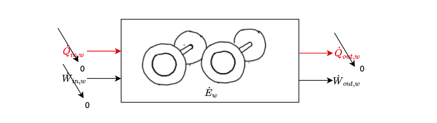

### First Law analysis of the toy truck's body

A general energetic diagram for the truck's body is shown below:

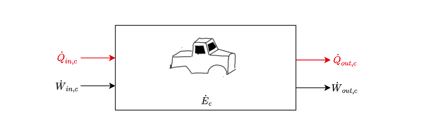

Once again, our starting point is writing the first law based on the diagram above.

$$\dot{E}_c = \dot{W}_{in,c}-\dot{W}_{out,c} + \dot{Q}_{in,c}-\dot{Q}_{out,c}$$

Again, we try to fill in this equation using what we know. The body of the truck stores kinetic energy. Because it is not rotating, it only stores *translational* kinetic energy. We also can assume that the truck is not gaining or losing mass. Therefore, we can write an expression for the energy stored in the truck's body at any moment as:

$$E_c = \frac{1}{2} m_c v^2$$

Then, taking the derivative of this quantity, which shows us how it *changes* over time, and writing the first law equation in terms of power, we get:

$$\dot{E}_c = m_c v \dot{v} = \dot{W}_{in,c}-\dot{W}_{out,c} + \dot{Q}_{in,c} - \dot{Q}_{out,c}$$

Like the axle, the car body is at the same temperature as the environment and the other components in our system. Like the axle, we can say that the temperature of the car body is also **outside the scope** of our system definition. So we will make the assumption that no heat transfer is involved in this first law balance. We also know that because nothing is acting to *increase* the car's kinetic energy during our experiments, we can say that the car's change in energy over time is negative, and thus the car body is **doing work** on the bearing. This leads to the following simplified first law equation:

$$ - m_c v \dot{v} = \dot{W}_{out,c}$$

And the following simplified energetic diagram:

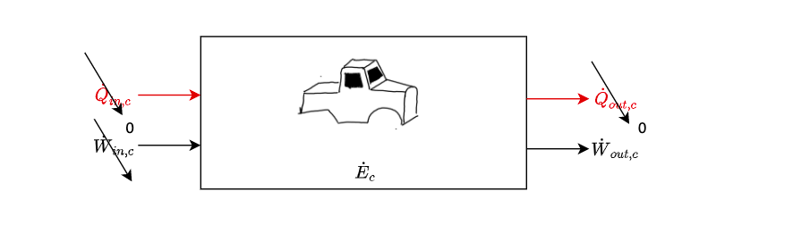

### First Law analysis of the toy truck's bearings

A general energetic diagram of the toy truck's bearings is shown below.

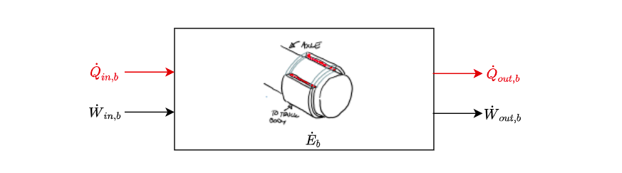

Thinking back to our modeling choices from Reading 7, we said that the bearing *had no significant mass*, because at least in the case of the toy truck, it really just exists as the lubricated interface between the rotating axle and the translating truck body. **If we make the assumption** that the bearing is "massless," then we can say that it **has no capacity to store kinetic, potential, or even thermal energy**. Therefore, we can say definitively that under our assumptions, the first law analysis for the bearing looks like:

$$\dot{E}_b = 0 = \dot{W}_{in,b} - \dot{W}_{out,b} + \dot{Q}_{in,b} - \dot{Q}_{out,b}$$

We can also say that because the bearing has no capacity to store its own energy, that *all of the power that is involved in spinning the bearing is the result of work done **on** the bearing*. This means that the work done on the bearing **must** be balanced by the production of heat which leaves the bearing and exits our model's scope.

Is this heat going "directly into the atmosphere" to warm up the room? Not necessarily. Technically it probably warms the truck body a little, and warms the axles a little. It probably warms the room even less, but by the first law, we know that the friction in the bearing must **produce heat** at a rate equal to the rate at which work is done on the bearing itself. Think about a ball of clay. This tracks with the "rubbing your hands" together example. With that said, we can write the first law for the bearing as:

$$\dot{W}_{in,b} = \dot{Q}_{out,b}$$

Further, we know from Reading 7 that the torque produced by the bearing is proportional to the difference in angular velocity of the inner and outer races. This means that we can actually write a mathematical expression for the rate of work done on the bearing as:

$$\dot{W}_{in,b} = T \Omega = b\Omega^2$$

This allows us to write an even more specific expression for the first law applied to the bearing as:

$$\dot{W}_{in,b} = \dot{Q}_{out,b} = b\Omega ^2$$

### Modeling energy transfer between elements in the toy truck energetic model

Now, looking at how all of the components in our model of the truck interact, we can draw an energetic diagram that shows how power flows between elements by drawing an energetic model of the whole toy truck model again, but now including the simplified first law analyses for each component. This is shown below.

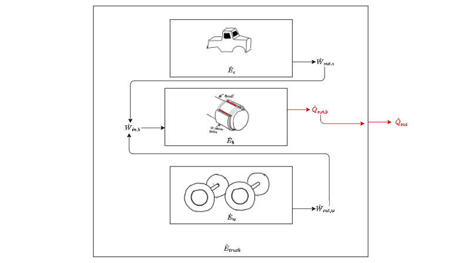

We know that overall, the system **only** exchanges energy with the environment in the form of heat being transferred from the bearing to the outside world. The only element in the system that transfers heat this way is the bearing, so the work coming out of the wheels and the body (since these aren't 'powered' and their energy goes down over time) must be done on the bearing, since this is the only thing they're connected to.

Looking at this diagram also allows us to be more specific about the first law analysis of the bearing, because we can see that the power applied to the bearing is **the sum** of the powers that flow out of the truck and the body to provide the total work applied to the bearing.

Writing the first law equation for the bearing and substituting our expressions for $\dot{W}_{out,w}$ and $\dot{W}_{out,c}$, we get:

$$\dot{W}_{in,b} = \dot{Q}_{out,b} = b\Omega ^2 = - m_c v \dot{v} -2(m_w v \dot{v} + J_w \Omega \dot{\Omega}) $$

Now, remembering that because the wheels roll without slip, $\Omega r_w = v$, where $r_w$ is the radius of the wheels, we can make another substitution to get all of the terms in the equation in terms of our desired output from our input-output model of the system.

$$ b\frac{v ^2}{r^2} = - m_c v \dot{v} -2(m_w v \dot{v} + J_w \frac{v}{r} \frac{\dot{v}}{r}) $$

this allows us to cancel an extra power of $v$ from the equation, which leaves us with:

$$ b \frac{v}{r^2} = - m_c \dot{v} -2(m_w \dot{v} + J_w \frac{\dot{v}}{r^2}) $$

When we clean this up and rearrange terms to obtain a differential equation relating velocity with acceleration, we get **the exact same model we got using Newton's laws**:

$$ \dot{v} = - \frac{1}{m_c+2m_w+2\frac{J}{r_{wg}^2}} \left[ 2\frac{b}{r_{w}^2} v \right]$$

This equation started off as a statement about the *conservation of energy over time* by relating the flow of power into and out of each "piece" of our system. Curiously, this statement is *equivalent* to a statement about the influence of forces on the masses in our system via Newton's second law!

This process shows that using the first law of thermodynamics can give us an equivalent system model to what we got using Newton's laws. Because writing kinetic and/or potential energy for a fluid is substantially easier than drawing a "free body diagram" for a fluid, this will be our ticket towards developing a unified approach to constructing models for physical systems of all different types.

# Assignment

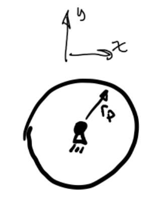

- The pulley has a radius of $0.1m$
- The pulley has a mass of $500g$.

Use the first law of thermodynamics (rather than Newton's laws) to produce your model. Your evaluation of the modeling choices you make should be based on whether the model you construct using the first law of thermodynamics agrees with your Newton's laws model. If you did not get your model to work correctly for Reading 7, you can re-evaluate your model here. Provide an input-output model describing system scope, any energetic diagrams you create during the construction of your model, and any hand calculations or analysis you used to derive your model in the appropriate cells below.

## Deliverables: Model Construction

If you need more markdown cells for images of your work, create them *in addition to* the one I have provided.

## Deliverables: Model Evaluation

```matlab
% YOUR CODE HERE
error('No Answer Given!')
```

[output not shown]